# Inspecting Markov Chain Behaviour

Prof. Gwen Eadie

2025-05-06

## Intended Learning Outcome

*Understand how to width of the proposal distribution affects the efficiency and sampling of a posterior distribution*

In this exercise, we will perform Bayesian inference for a linear regression and play around with the width of the proposal distribution to see how this affects the resulting Markov chain.

For learning purposes, we won’t use an out-of-the-box MCMC package to do the sampling. We will write our own, very simplistic, Metroplis algorithm (everyone should do this at least once, it’s a good learning experience!). We will assume uniform priors on the parameters, meaning that these are constants and can be ignored/left out in the code. (However, in practice, you should always think carefully about the priors and definitely include them!!).

### Step 1

Simulate some mock data ($n=100$) that follows the line
$$y = \beta_0 + \beta_1
x$$
and set the parameters to some true values of your choice. When simulating the data, make sure to include some Gaussian, random noise. I recommend setting $\sigma=1$, although you can choose how noisy you want your data to be.

```r
# set seed
set.seed(42)

# number of data points
N <- 100

# simulate some x values
x <- rnorm(N, mean = 5, sd = 2)

# define the true intercept and slope
beta0 <- 1.5
beta1 <- 0.65

# set the standard deviation of noise
sigma <- 1

# Simulate the corresponding mock y data given the model
y <- beta0 + beta1 * x + rnorm(N, 0, sigma)

# make data frame
mydata = data.frame(x=x, y=y)
```

### Step 2

Write the log-likelihood function that will take in the parameters for the intercept and slope, and the mock data.

```r
# Log-likelihood function
loglike <- function(intercept, slope, x, y) {
  y_pred <- intercept + slope * x
  sum(dnorm(y, mean = y_pred, sd = sigma, log = TRUE))
}
```

### Step 3

Decide on the length of the chain, the initial values of the parameters for the chain, and the width (standard deviation) of the proposal distribution. We will use a Gaussian proposal distribution.

```r
# length of chain
iterations <- 1000

# make an empty matrix that will be filled as the Markov chain is made
chain <- matrix(NA, nrow = iterations, ncol = 2)

# Initial values
chain[1, 1] <- 0
chain[1, 2] <- 0

# Proposal standard deviations for each parameter
prop_sd_beta0 <- 0.2
prop_sd_beta1 <- 0.2
```

### Step 4

Write a basic Metroplis algorithm to sample from the posterior distribution (remember, we are assuming constant priors so you can leave those out since they are constants). For the step where you compute the acceptance ratio $r$, you need to calculate

$$r = \frac{p(\beta_0^*,
\beta_1^*|x)}{p(\beta_{0, i-1}, \beta_{1,i-1}|x)}$$
I recommend doing this in log space, i.e.,

$$\log{r} = \log{(p(\beta_0^*,
\beta_1^*|x))} - \log{(p(\beta_{0, i-1},
\beta_{1,i-1}|x))}$$
.

Then, compare $\log{r}$ to $\log{(x)}$, where $x$ is a random number drawn from $U(0,1)$. This will be more computationally efficient.

```r
# write the Metroplis algorithm (a simple for-loop will do the trick, and should be very quick for this model)

MetAlg = function(x,y, MarkovChain, propsd0, propsd1, n){

  for(i in 2:n){
    # Propose new values for beta0 and beta1
    beta0star <- rnorm(1, mean = MarkovChain[i-1, 1], sd = propsd0)
    beta1star  <- rnorm(1, mean = MarkovChain[i-1, 2], sd = propsd1)

    # Compute acceptance ratio
    log_r <- loglike(beta0star, beta1star, x,y) - loglike(MarkovChain[i-1,1], MarkovChain[i-1, 2], x,y)

    # Accept/reject step
    if(log(runif(1)) < log_r){
      MarkovChain[i, ] <- c(beta0star, beta1star)
      }else{
        MarkovChain[i, ] <- MarkovChain[i-1, ]
      }
    }
  MarkovChain
}



postsamples <- MetAlg(x=x, y=y, MarkovChain=chain, propsd0=prop_sd_beta0, propsd1 = prop_sd_beta1, n=iterations)
```

### Step 5

Make a trace plot of the chain to look at its behaviour.

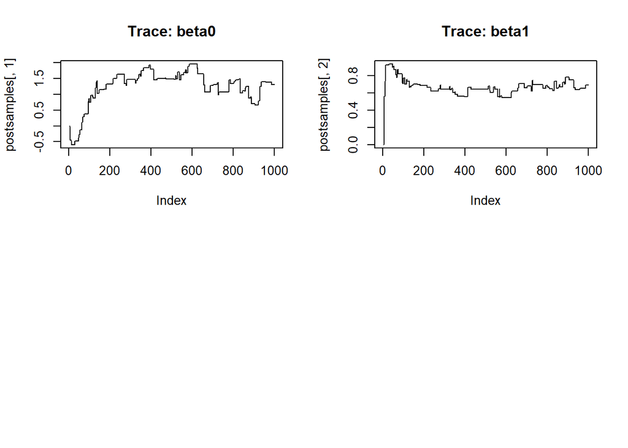

```r
# Plot the results
par(mfrow = c(2, 2))
plot(postsamples[,1], type = "l", main = "Trace: beta0")
plot(postsamples[,2], type = "l", main = "Trace: beta1")
```

Now try different proposal distribution widths and see how this affects the chain.

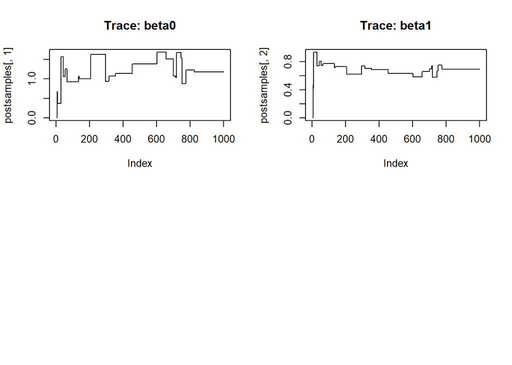

```r
# larger sd
prop_sd_beta0 <- 0.6
prop_sd_beta1 <- 0.6

postsamples <- MetAlg(x,y, MarkovChain=chain, propsd0=prop_sd_beta0, propsd1 = prop_sd_beta1, n=iterations)

par(mfrow = c(2, 2))
plot(postsamples[,1], type = "l", main = "Trace: beta0")
plot(postsamples[,2], type = "l", main = "Trace: beta1")

# smaller sd
prop_sd_beta0 <- 0.1
prop_sd_beta1 <- 0.1

postsamples <- MetAlg(x,y, MarkovChain=chain, propsd0=prop_sd_beta0, propsd1 = prop_sd_beta1, n=iterations)

par(mfrow = c(2, 2))
```

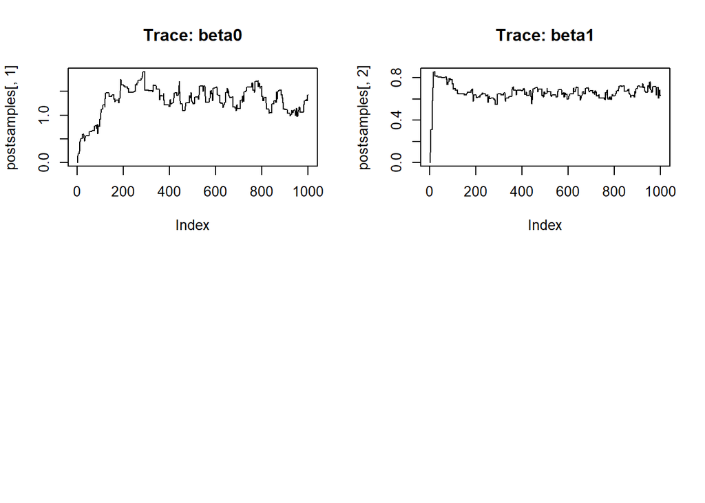

```r
plot(postsamples[,1], type = "l", main = "Trace: beta0")
plot(postsamples[,2], type = "l", main = "Trace: beta1")

# even smaller sd
prop_sd_beta0 <- 0.006
prop_sd_beta1 <- 0.006

postsamples <- MetAlg(x,y, MarkovChain=chain, propsd0=prop_sd_beta0, propsd1 = prop_sd_beta1, n=iterations)

par(mfrow = c(2, 2))
```

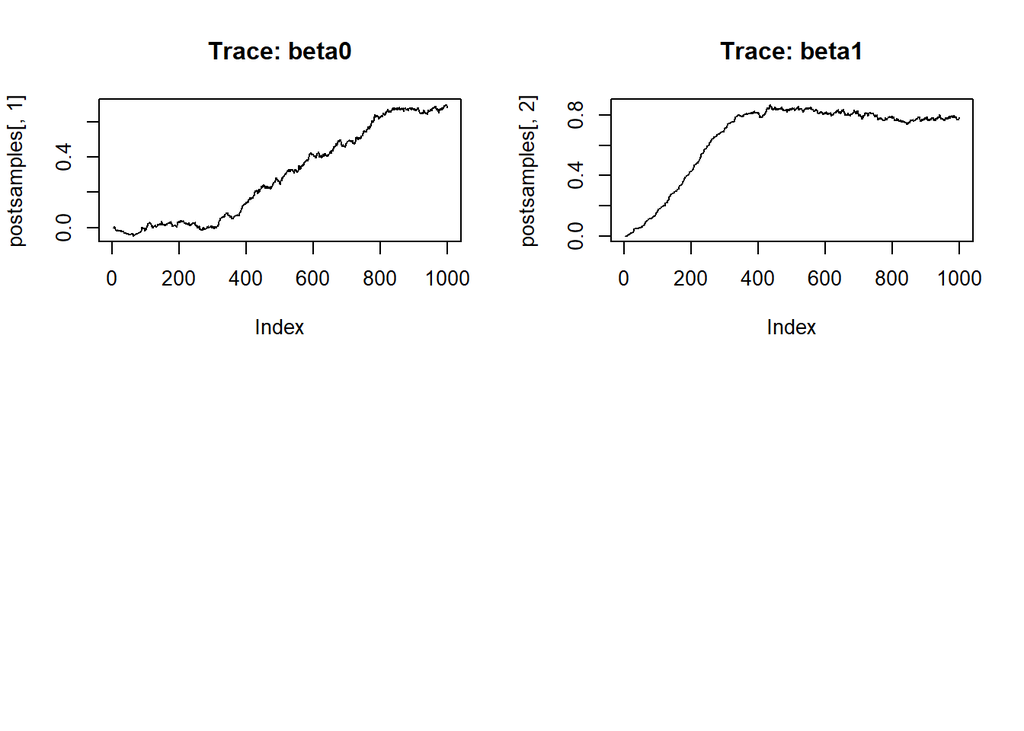

```r
plot(postsamples[,1], type = "l", main = "Trace: beta0")
plot(postsamples[,2], type = "l", main = "Trace: beta1")


# good sd
prop_sd_beta0 <- 0.2
prop_sd_beta1 <- 0.2

iterations = 1e4
# make an empty matrix that will be filled as the Markov chain is made
chain <- matrix(NA, nrow = iterations, ncol = 2)

# Initial values
chain[1, 1] <- 0
chain[1, 2] <- 0

postsamples <- MetAlg(x, y, MarkovChain=chain, propsd0=prop_sd_beta0, propsd1 = prop_sd_beta1, n=iterations)

par(mfrow = c(2, 2))
```

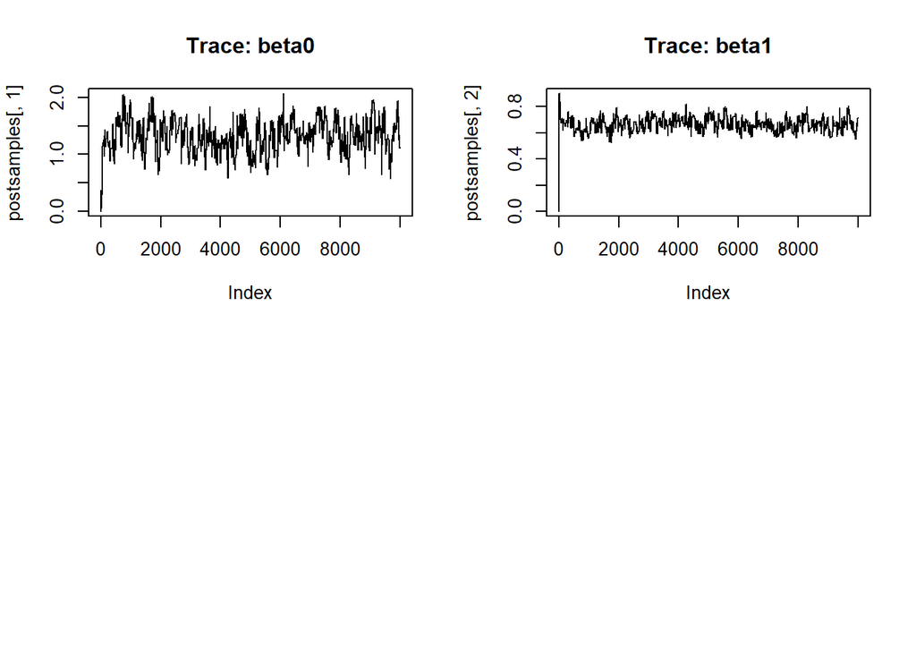

```r
plot(postsamples[,1], type = "l", main = "Trace: beta0")
plot(postsamples[,2], type = "l", main = "Trace: beta1")
```

Extra exercise: add to your Metropolis function a way to keep track of the *acceptance rate* — the percentage of the time that the suggested values $\beta_0^*,\beta_1^*$ are accepted. A good acceptance rate for a simple Metropolis algorithm with only a few parameters should be somewhere between 20-40%.

### Step 6

Once you’ve settled on a good proposal distribution and the trace plots look good, then discard the burn-in and look at the marginal distribution for each parameter. Were you able to recover the true parameter values?

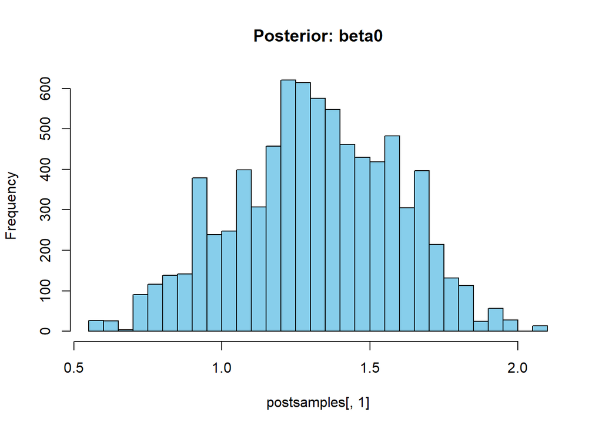

```r
postsamples = postsamples[2000:iterations, ]
# Look at the marginal distribution for each parameter
hist(postsamples[,1], breaks = 40, main = "Posterior: beta0", col = "skyblue")
```

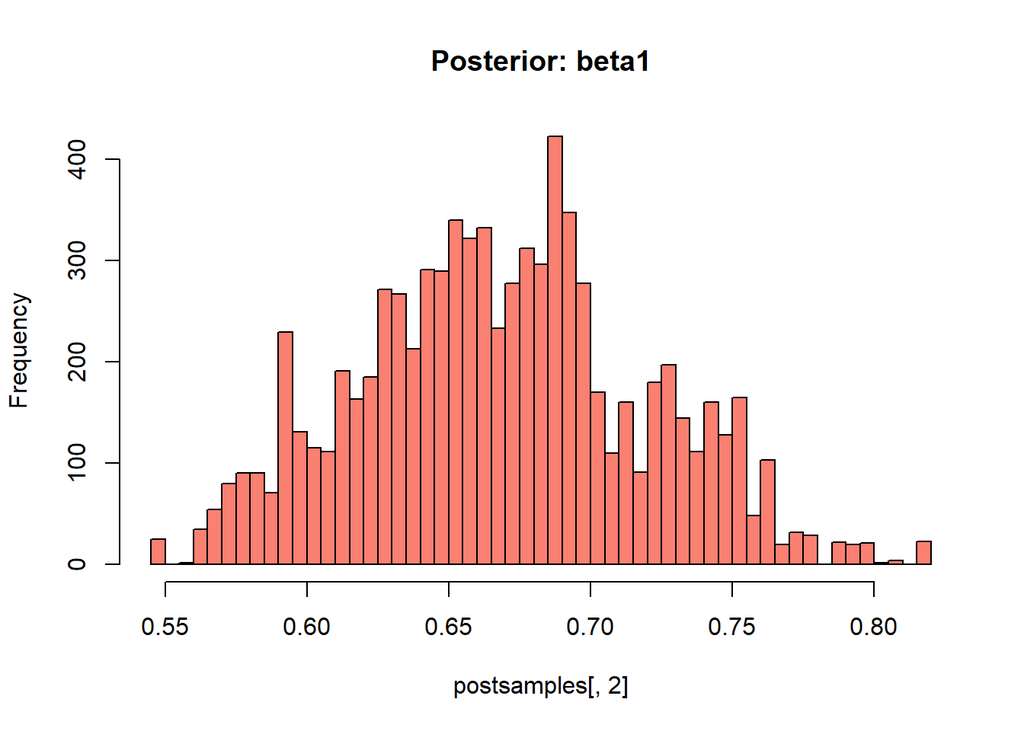

```r
hist(postsamples[,2], breaks = 40, main = "Posterior: beta1", col = "salmon")
```

Also look at the full posterior distribution — notice that the intercept and slope are highly correlated! Using a joint proposal distribution for $\beta_0$ and $\beta_1$ with some covariance matrix would be more efficient.

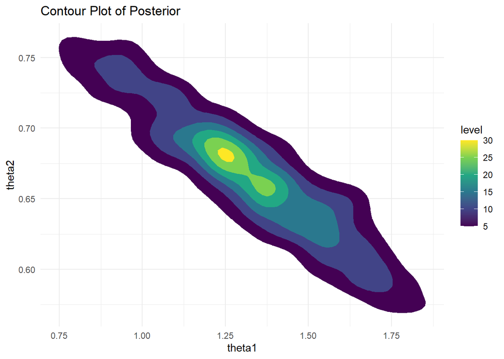

```r
library(ggplot2)

# Simulated data
df <- data.frame(beta0=postsamples[,1], beta1=postsamples[,2])

# Create the plot
ggplot(df, aes(x = beta0, y = beta1)) +
  stat_density_2d(aes(fill = ..level..), geom = "polygon") +
  scale_fill_viridis_c() +
  labs(title = "Contour Plot of Posterior", x = "theta1", y = "theta2") +
  theme_minimal()
```